# Day 3: Hierarchical models

Author

Masatoshi Katabuchi

Published

October 23, 2026

# Mother-tree survival

We observed seedling survival under eight mother trees of one species. A hierarchical binomial model gives each tree its own survival probability and connects the tree intercepts through a shared distribution.

$$s_j \sim \operatorname{Binomial}(n_j,p_j), \qquad
\operatorname{logit}(p_j)=z_j, \qquad
z_j\sim\mathcal{N}(\mu,\sigma).$$

There is no density predictor in this model: each tree has one intercept and one survival probability. The shared centre $\mu$ and between-tree SD $\sigma$ are estimated along with the tree intercepts. The priors are $\mu\sim\mathcal{N}(0,5)$ and $\sigma\sim\operatorname{HalfNormal}(0,1)$, on the logit scale. Univariate Normal distributions use standard deviations as their second arguments.

**Core:** read the mother-tree model and prepared results, then follow the three regression structures. Running the supplied code is optional.

**Optional reference:** new fitting and the complete second regression analysis.

## Packages and data

```r
library(tidyverse)
library(posterior)
library(bayesplot)
library(here)
theme_set(theme_bw(base_size = 14))

trees <- read_csv(here("data", "trees.csv"))
trees |>
  select(tree, n, suv) |>
  mutate(observed_proportion = suv / n)
```

```
#> # A tibble: 8 × 4
#>   tree      n   suv observed_proportion
#>   <chr> <dbl> <dbl>               <dbl>
#> 1 A        15     6              0.4
#> 2 B        39    18              0.462
#> 3 C        24     6              0.25
#> 4 D        50    19              0.38
#> 5 E        32     6              0.188
#> 6 F        38    12              0.316
#> 7 G        21     1              0.0476
#> 8 H        50    12              0.24
```

`n` is the number of seedlings and `suv` the number of survivors. These are the same counts used in the lecture’s comparison plots.

## Stan model

The file `stan/logistic.stan` contains the full model:

```stan
data {
  int<lower=1> I; // number of species
  array[I] int<lower=0> suv; // number of survivors
  array[I] int<lower=0> N; // number of individuals
  array[I] int<lower=1, upper=I> ii; // integer
}

parameters {
  real mu;
  real<lower=0> sigma;
  vector[I] z_tilde;
}

transformed parameters {
  vector[I] z;
  z = mu + sigma * z_tilde;
}

model {
  mu ~ normal(0, 5);
  z_tilde ~ std_normal();
  sigma ~ std_normal();
  for (i in 1:I)
    suv[i] ~ binomial_logit(N[i], z[ii[i]]);
}

generated quantities {
  vector[I] log_lik;
  vector[I] p = inv_logit(z);
  for (i in 1:I)
    log_lik[i] = binomial_logit_lpmf(suv[i] | N[i], z[ii[i]]);
}
```

The file’s legacy comment says species; here each group is a mother tree. `I` is the number of trees, `N` their seedling counts and `ii` the group index. `binomial_logit(N, z)` is a binomial model with probability `inv_logit(z)`.

The pair `z_tilde ~ std_normal()` and `z = mu + sigma * z_tilde` implies $z_j\sim\mathcal{N}(\mu,\sigma)$ conditional on the shared parameters. This is a **non-centered parameterization** of the same group model. All trees inform `mu` and `sigma`, connecting their intercept estimates. Non-centering changes how the model is represented for computation; it does not add a density effect.

Because `sigma` is constrained to be positive, `sigma ~ std_normal()` specifies the half-Normal prior. Its scale describes between-tree variation in logit intercepts, not variation in the observed survivor counts. `p = inv_logit(z)` returns tree survival probabilities for each posterior draw.

## Optional: fit the model with Stan

The data list connects the observed counts to Stan’s data block.

```r
stan_data <- list(
  I = nrow(trees),
  ii = seq_len(nrow(trees)),
  suv = as.integer(trees$suv),
  N = as.integer(trees$n)
)
stan_data
```

```
#> $I
#> [1] 8
#>
#> $ii
#> [1] 1 2 3 4 5 6 7 8
#>
#> $suv
#> [1]  6 18  6 19  6 12  1 12
#>
#> $N
#> [1] 15 39 24 50 32 38 21 50
```

`cmdstan_model()` compiles the supplied file and `$sample()` runs the chains. This chunk runs new inference in a prepared environment. It is shown but not executed when this handout is rendered; the saved-result route below skips compilation and sampling.

```r
library(cmdstanr)

model_stan <- cmdstan_model(here("stan", "logistic.stan"))
fit_stan <- model_stan$sample(
  data = stan_data,
  seed = 123,
  chains = 4,
  parallel_chains = 1,
  iter_warmup = 1000,
  iter_sampling = 1000,
  refresh = 500
)
```

## Posterior draws

Use **one** of the following chunks, then continue to Summary. Use the Stan result after fitting, or the prepared result to skip fitting. The later code uses the draws and diagnostics from the chosen result.

### Stan result

```r
draws <- as_draws_df(fit_stan$draws())
sampler_diagnostics <- fit_stan$diagnostic_summary()
```

### Prepared result

```r
fit <- readRDS(here("fits", "day3_trees.rds"))
stopifnot(
  isTRUE(all.equal(stan_data, fit$data, check.attributes = FALSE)),
  identical(fit$meta$stan_file, "stan/logistic.stan")
)
draws <- fit$draws
sampler_diagnostics <- fit$diagnostics
```

The checks confirm that the saved result belongs to these data and this model. Changing the counts or model requires a new fit. New inference can differ slightly from the prepared result because of Monte Carlo variation.

## Summary

The shared parameters and the tree-specific intercepts are on the logit scale.

```r
intercept_draws <- subset_draws(
  draws,
  variable = c("mu", "sigma", paste0("z[", stan_data$ii, "]"))
)
intercept_table <- summarise_draws(
  intercept_draws,
  mean = mean,
  sd = sd,
  \(x) quantile(x, probs = c(0.025, 0.975))
)
intercept_table
```

```
#> # A tibble: 10 × 5
#>    variable   mean    sd  `2.5%` `97.5%`
#>    <chr>     <dbl> <dbl>   <dbl>   <dbl>
#>  1 mu       -0.957 0.270 -1.56    -0.469
#>  2 sigma     0.570 0.291  0.0803   1.25
#>  3 z[1]     -0.693 0.409 -1.47     0.175
#>  4 z[2]     -0.409 0.317 -1.01     0.210
#>  5 z[3]     -1.03  0.370 -1.81    -0.349
#>  6 z[4]     -0.626 0.267 -1.14    -0.102
#>  7 z[5]     -1.26  0.372 -2.06    -0.632
#>  8 z[6]     -0.843 0.294 -1.44    -0.271
#>  9 z[7]     -1.67  0.615 -3.07    -0.718
#> 10 z[8]     -1.09  0.286 -1.70    -0.587
```

`mu` describes the shared centre and `sigma` the between-tree SD. Neither is a tree’s survival probability. The `z[j]` rows describe each tree’s intercept.

Stan already saves the corresponding probability draws as `p[j]`.

```r
probability_variables <- paste0("p[", stan_data$ii, "]")
probability_draws <- subset_draws(draws, variable = probability_variables)
probability_table <- summarise_draws(
  probability_draws,
  mean = mean,
  sd = sd,
  \(x) quantile(x, probs = c(0.025, 0.975))
) |>
  mutate(
    tree = trees$tree[match(variable, probability_variables)],
    .before = 1
  )
probability_table
```

```
#> # A tibble: 8 × 6
#>   tree  variable  mean     sd `2.5%` `97.5%`
#>   <chr> <chr>    <dbl>  <dbl>  <dbl>   <dbl>
#> 1 A     p[1]     0.339 0.0894 0.187    0.544
#> 2 B     p[2]     0.402 0.0748 0.268    0.552
#> 3 C     p[3]     0.269 0.0697 0.141    0.414
#> 4 D     p[4]     0.351 0.0601 0.243    0.475
#> 5 E     p[5]     0.228 0.0614 0.113    0.347
#> 6 F     p[6]     0.304 0.0612 0.192    0.433
#> 7 G     p[7]     0.174 0.0764 0.0442   0.328
#> 8 H     p[8]     0.255 0.0526 0.155    0.357
```

The mean and 2.5th/97.5th percentiles are the partial-pooling point and 95% credible interval shown in the lecture. Here `sd` describes posterior uncertainty about a probability; it is different from the group parameter `sigma`.

For Tree A, we can also calculate the transformation directly in R:

```r
alpha_a <- draws[["z[1]"]]
p_a <- plogis(alpha_a)
survival_summary <- tibble(
  tree = "A",
  mean = mean(p_a),
  lower = unname(quantile(p_a, 0.025)),
  upper = unname(quantile(p_a, 0.975))
)
survival_summary
```

```
#> # A tibble: 1 × 4
#>   tree   mean lower upper
#>   <chr> <dbl> <dbl> <dbl>
#> 1 A     0.339 0.187 0.544
```

`plogis()` in R is `inv_logit()` in Stan. Transform each draw before summarizing: `plogis(mean(alpha_a))` is generally not the posterior mean of the probability. These are draws of a probability, not future survivor counts.

## Sampling diagnostics

```r
sampling_table <- summarise_draws(
  intercept_draws,
  rhat = posterior::rhat,
  ess_bulk = posterior::ess_bulk,
  ess_tail = posterior::ess_tail
)
sampling_table
```

```
#> # A tibble: 10 × 4
#>    variable  rhat ess_bulk ess_tail
#>    <chr>    <dbl>    <dbl>    <dbl>
#>  1 mu       1.00     1169.    1079.
#>  2 sigma    1.00      972.    1121.
#>  3 z[1]     1.00     3556.    2938.
#>  4 z[2]     1.00     2378.    2589.
#>  5 z[3]     1.00     3757.    3262.
#>  6 z[4]     1.00     4152.    3246.
#>  7 z[5]     1.000    2575.    3176.
#>  8 z[6]     1.000    5461.    3137.
#>  9 z[7]     1.00     1682.    2726.
#> 10 z[8]     1.000    3976.    3414.
```

```r
sampler_table <- as_tibble(sampler_diagnostics) |>
  mutate(chain = row_number(), .before = 1)
sampler_table
```

```
#> # A tibble: 4 × 4
#>   chain num_divergent num_max_treedepth ebfmi
#>   <int>         <dbl>             <int> <dbl>
#> 1     1             0                 0 0.670
#> 2     2             0                 0 0.676
#> 3     3             0                 0 0.657
#> 4     4             0                 0 0.699
```

- `rhat` compares chains; values above 1.01 warrant investigation.
- `ess_bulk` and `ess_tail` describe effective sample sizes for central values and tails. For these four chains, values below about 400 warrant investigation.
- `num_divergent` counts divergent transitions after warmup; investigate any nonzero count. Also inspect `num_max_treedepth` and `ebfmi`.

Read these checks alongside the traces. Encouraging numbers do not prove convergence or that the ecological model is appropriate. If a new fit was run, use its own diagnostics rather than the prepared result’s diagnostics.

## Trace plots

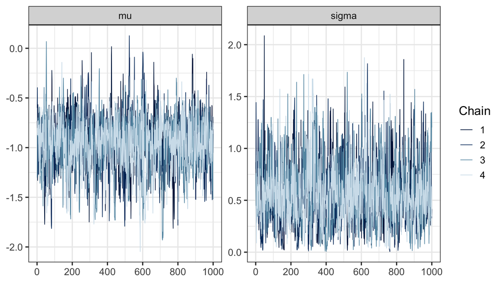

```r
bayesplot::mcmc_trace(draws, pars = c("mu", "sigma"))
```

The horizontal axis is the saved post-warmup sampling step, and colours identify chains. Look for persistent separation, drift or poor exploration. Overlap alone is not enough; interpret the traces with the numerical diagnostics.

## Can the model reproduce the observed counts?

Use the posterior probability for each mother tree to generate another survivor count. Keep the observed number of seedlings fixed:

$$\widetilde{s}_j^{(m)}\sim\operatorname{Binomial}(n_j,p_j^{(m)}).$$

Here $m$ indexes posterior draws. The replicated counts include both uncertainty in survival probability and binomial sampling variation.

```r
set.seed(20261025)
probability_matrix <- as_draws_matrix(probability_draws)
replicated_counts <- matrix(
  NA_integer_,
  nrow = nrow(probability_matrix),
  ncol = nrow(trees)
)
for (j in seq_len(nrow(trees))) {
  replicated_counts[, j] <- rbinom(
    nrow(probability_matrix),
    size = trees$n[j],
    prob = probability_matrix[, probability_variables[j]]
  )
}

replicated_summary <- tibble(
  tree = trees$tree,
  observed = trees$suv,
  lower = apply(replicated_counts, 2, quantile, probs = 0.025),
  median = apply(replicated_counts, 2, median),
  upper = apply(replicated_counts, 2, quantile, probs = 0.975)
)
replicated_summary
```

```
#> # A tibble: 8 × 5
#>   tree  observed lower median upper
#>   <chr>    <dbl> <dbl>  <dbl> <dbl>
#> 1 A            6     1      5    10
#> 2 B           18     8     15    24
#> 3 C            6     2      6    12
#> 4 D           19     9     17    27
#> 5 E            6     2      7    14
#> 6 F           12     5     11    19
#> 7 G            1     0      3     9
#> 8 H           12     5     13    21
```

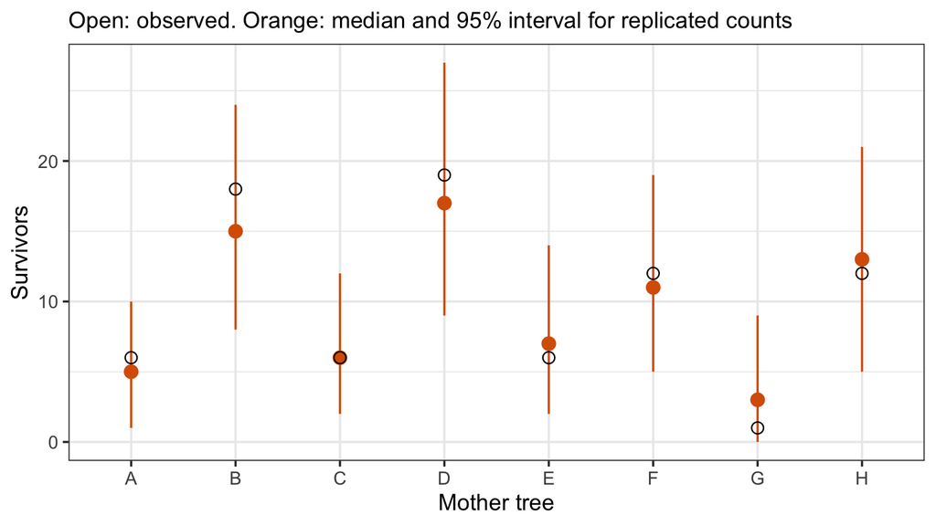

```r
predictive_plot <- ggplot(replicated_summary, aes(tree, median)) +
  geom_pointrange(
    aes(ymin = lower, ymax = upper),
    colour = "#d95f02"
  ) +
  geom_point(aes(y = observed), shape = 1, size = 3) +
  labs(
    x = "Mother tree",
    y = "Survivors",
    subtitle = paste(
      "Open: observed.",
      "Orange: median and 95% interval for replicated counts"
    )
  )
predictive_plot
```

The orange intervals describe **replicated survivor counts**, whereas the earlier credible intervals described **survival probabilities**. Ask whether the observed counts look compatible with the replicated counts, and whether any trees show a systematic discrepancy. These are checks at the observed seedling counts, not predictions for a new mother tree.

This plot checks the observations, not the sampler. Assess it together with the sampling checks and the ecological reasons for sharing information. Agreement alone does not establish that all model assumptions are adequate.

# From intercepts to regression

The mother-tree model estimated one probability per group. Now ask: **how does survival change with local conspecific density, and does the response differ among species?** Adding a predictor turns the intercept-only model into a regression. We use species as groups for this new question.

## Data

Use one simulated data set for all three models: 12 species with 3–24 quadrats each. Each row records `suv` survivors out of `n` seedlings. Local density varies within species; wood density is a species-level trait, constant within species. The lecture uses abundance in the same role as wood density here. The original allometry examples use the same hierarchy with a Normal observation model.

**In class:** focus on the three model equations and formulas below. The simulation code and the complete saved-fit walkthrough are reference material for later reading.

| Variable | Meaning |
| --- | --- |
| `x` | (Conspecific neighbours − 20) / 10; zero means 20 neighbours |
| `u` | Wood density (g/cm³), standardized across the 12 species |
| `species` | Group label |

The code below creates the data. Expand it to inspect or run the full simulation. The known `_true` values are used only to simulate observations, never for fitting.

**Show R code**

```r
set.seed(20261026)
species_info <- tibble(
  species = LETTERS[1:12],
  quadrats = c(24L, 20L, 16L, 12L, 10L, 8L, 7L, 6L, 5L, 4L, 3L, 3L),
  wood_density = c(0.52, 0.77, 0.39, 0.66, 0.43, 0.81,
                   0.58, 0.35, 0.71, 0.48, 0.63, 0.74)
) |>
  mutate(u = as.numeric(scale(wood_density)))

# Correlated residual intercept and slope deviations.
z_alpha <- rnorm(nrow(species_info))
z_beta <- rnorm(nrow(species_info))
species_info <- species_info |>
  mutate(
    alpha_true = -0.3 + 0.3 * u + 0.45 * z_alpha,
    beta_true = -1 +
      0.6 * u +
      0.3 * (0.25 * z_alpha + sqrt(1 - 0.25^2) * z_beta)
  )

reg_data <- species_info |>
  uncount(quadrats, .id = "quadrat") |>
  mutate(
    species = factor(species, levels = species_info$species),
    density = runif(n(), min = 5, max = 35),
    x = (density - 20) / 10,
    n = sample(12:30, n(), replace = TRUE),
    p_true = plogis(alpha_true + beta_true * x),
    suv = rbinom(n(), size = n, prob = p_true)
  )
reg_data |>
  select(species, quadrat, density, x, wood_density, u, n, suv) |>
  head(6)
```

```
#> # A tibble: 6 × 8
#>   species quadrat density       x wood_density      u     n   suv
#>   <fct>     <int>   <dbl>   <dbl>        <dbl>  <dbl> <int> <int>
#> 1 A             1    25.1  0.508          0.52 -0.446    22     5
#> 2 A             2    34.4  1.44           0.52 -0.446    30     3
#> 3 A             3    19.8 -0.0244         0.52 -0.446    14     6
#> 4 A             4    30.1  1.01           0.52 -0.446    17     2
#> 5 A             5    34.4  1.44           0.52 -0.446    13     1
#> 6 A             6    23.6  0.362          0.52 -0.446    12     4
```

All three models use the same binomial likelihood and logit link, with quadrat $i$ in species $j$:

$$s_{ij}\sim\operatorname{Binomial}(n_{ij},p_{ij}),\qquad
\operatorname{logit}(p_{ij})=\eta_{ij}.$$

## Model 1: Varying intercepts

$$\eta_{ij}=\alpha_j+\beta x_{ij},\qquad
\alpha_j\sim\mathcal N(\mu_\alpha,\sigma_\alpha).$$

Species differ in survival at the reference density: `plogis(alpha_j)`. Their intercepts receive partial pooling through the shared mean $\mu_\alpha$ and SD $\sigma_\alpha$. The density slope $\beta$ is common to all species; a negative slope represents conspecific negative density dependence (CNDD). The lines are parallel on the logit scale, not necessarily on the probability scale.

```r
f_intercepts <- suv | trials(n) ~ x + (1 | species)
```

Use this and the following formulas with `family = binomial(link = "logit")`. `(1 | species)` adds a species intercept deviation to the population intercept.

## Model 2: Varying intercepts and slopes

$$\eta_{ij}=\alpha_j+\beta_jx_{ij},\qquad
\alpha_j\sim\mathcal N(\mu_\alpha,\sigma_\alpha),\qquad
\beta_j\sim\mathcal N(\mu_\beta,\sigma_\beta).$$

Now the response to density can differ among species. **Slopes also receive partial pooling** toward the shared mean $\mu_\beta$. Weakly informed species borrow more information; the number of quadrats, density range and survival outcomes all affect how well a slope is estimated.

```r
f_slopes <- suv | trials(n) ~ x + (1 + x | species)
```

The Normal statements describe the marginal distributions. The single bar in `(1 + x | species)` also models the correlation between intercept and slope deviations; `||` would omit it. See the [brms formula documentation](https://paulbuerkner.com/brms/reference/brmsformula.html).

## Model 3: Group-level predictors

Can wood density explain differences in CNDD? Let the mean slope depend on species trait $u_j$:

$$\beta_j\sim\mathcal N(\gamma_0+\gamma_1u_j,\sigma_\beta).$$

$\gamma_0$ is the expected slope at average wood density. A positive $\gamma_1$ means that a negative density response becomes less negative as wood density increases. Allow the trait to predict the intercept too:

$$\begin{aligned}
\alpha_j&=\delta_0+\delta_1u_j+a_j,\\
\beta_j&=\gamma_0+\gamma_1u_j+b_j.
\end{aligned}$$

The residual deviations $(a_j,b_j)$ have a joint Normal distribution with mean zero, SDs $\sigma_\alpha,\sigma_\beta$ and correlation $\rho$. Substituting gives

$$\eta_{ij}=\underbrace{\delta_0+\gamma_0x_{ij}+\delta_1u_j+
\gamma_1x_{ij}u_j}_{\text{population effects}}
+\underbrace{a_j+b_jx_{ij}}_{\text{species deviations}}.$$

The product $x_{ij}u_j$ appears because the density slope depends on a species trait: a **cross-level interaction**. In R, `x * u` expands to `x + u + x:u`:

```r
f_traits <- suv | trials(n) ~ x * u + (1 + x | species)
# x * u expands to x + u + x:u (with an intercept by default).
```

The `u` main effect comes from the intercept equation; a trait-dependent slope alone would give `x + x:u`. Slopes now pool toward the trait-dependent mean $\gamma_0+\gamma_1u_j$. Repeated quadrats help estimate slopes, but do not add independent species trait values.

## Optional walkthrough: read the saved regression results

Load the three prepared Stan fits; no compilation or new sampling is needed. Population coefficients have Normal(0, 1.5) priors on the logit scale; group SDs have HalfNormal(0, 0.7) priors. Models 2–3 use LKJ(2) for the residual correlation. These scales are tied to `x` and `u` above and should be reconsidered for new data.

```r
regression_fits <- list(
  intercepts = readRDS(here("fits", "day3_cndd_intercepts.rds")),
  slopes = readRDS(here("fits", "day3_cndd_slopes.rds")),
  traits = readRDS(here("fits", "day3_cndd_traits.rds"))
)
```

**NoteCheck that the saved fits match the data and model**

The switches `K` and `T` select varying coefficients and trait predictors in the shared Stan file. These checks stop if you change inputs or the model; changing data requires a new fit.

```r
regression_base <- list(
  N = nrow(reg_data),
  J = nrow(species_info),
  species = as.integer(reg_data$species),
  n = as.integer(reg_data$n),
  suv = as.integer(reg_data$suv),
  x = reg_data$x,
  u = species_info$u
)
regression_inputs <- list(
  intercepts = c(regression_base, list(K = 1L, T = 1L)),
  slopes = c(regression_base, list(K = 2L, T = 1L)),
  traits = c(regression_base, list(K = 2L, T = 2L))
)
```

```r
for (model_name in names(regression_fits)) {
  saved <- regression_fits[[model_name]]
  stopifnot(
    isTRUE(all.equal(saved$data, regression_inputs[[model_name]])),
    saved$meta$stan_file == "stan/cndd_hierarchical.stan",
    saved$meta$stan_md5 ==
      unname(tools::md5sum(here("stan", "cndd_hierarchical.stan")))
  )
}
```

For Model 3, the saved coefficient names map to the equations as follows:

| Variable | Meaning |
| --- | --- |
| `gamma[1,1]`, `gamma[1,2]` | Intercept mean: $\delta_0$, trait effect $\delta_1$ |
| `gamma[2,1]`, `gamma[2,2]` | Slope mean: $\gamma_0$, interaction $\gamma_1$ |
| `tau[1]`, `tau[2]` | Residual between-species intercept and slope SDs |

```r
trait_coefficients <- regression_fits$traits$draws
summarise_draws(
  subset_draws(trait_coefficients, variable = c("gamma", "tau")),
  mean, sd, ~quantile(.x, c(0.025, 0.975)), rhat, ess_bulk
)
```

```
#> # A tibble: 6 × 7
#>   variable     mean    sd `2.5%` `97.5%`  rhat ess_bulk
#>   <chr>       <dbl> <dbl>  <dbl>   <dbl> <dbl>    <dbl>
#> 1 gamma[1,1] -0.321 0.149 -0.605 -0.0286 1.00     1444.
#> 2 gamma[2,1] -1.05  0.180 -1.41  -0.692  1.00     1856.
#> 3 gamma[1,2]  0.129 0.163 -0.188  0.457  1.00     1717.
#> 4 gamma[2,2]  0.477 0.179  0.129  0.839  1.00     1921.
#> 5 tau[1]      0.483 0.139  0.276  0.836  0.999    1374.
#> 6 tau[2]      0.507 0.179  0.221  0.912  1.00     1518.
```

```r
interaction_draws <- trait_coefficients[["gamma[2,2]"]]
interaction_summary <- tibble(
  median = median(interaction_draws),
  lower = quantile(interaction_draws, 0.025),
  upper = quantile(interaction_draws, 0.975)
)
```

The median interaction is 0.48 (95% credible interval [0.13, 0.84]). A one-SD increase in wood density changes the expected density slope by this amount on the log-odds scale. This simulated example supports a weaker negative density response at higher wood density; it is not evidence about a real forest.

## Optional walkthrough: compare fitted survival curves

For each draw, calculate `plogis(alpha[j] + beta[j] * x)` before summarizing. The saved `alpha[j]` and `beta[j]` are total species coefficients. Using paired draws preserves their uncertainty and correlation.

**Show R code**

```r
curve_grid <- seq(-1.5, 1.5, length.out = 61)
regression_curves <- list()
row_id <- 0L
for (model_name in names(regression_fits)) {
  reg_draws <- regression_fits[[model_name]]$draws
  for (j in seq_len(nrow(species_info))) {
    alpha_draws <- reg_draws[[paste0("alpha[", j, "]")]]
    beta_draws <- reg_draws[[paste0("beta[", j, "]")]]
    eta_draws <- outer(beta_draws, curve_grid)
    eta_draws <- sweep(eta_draws, 1, alpha_draws, "+")
    probability_draws_grid <- plogis(eta_draws)
    row_id <- row_id + 1L
    regression_curves[[ row_id]] <- tibble(
      model = model_name,
      species = species_info$species[j],
      x = curve_grid,
      median = apply(probability_draws_grid, 2, median),
      lower = apply(probability_draws_grid, 2, quantile, probs = 0.025),
      upper = apply(probability_draws_grid, 2, quantile, probs = 0.975)
    )
  }
}
regression_curves <- bind_rows(regression_curves) |>
  mutate(model = factor(model, levels = names(regression_fits)))
```

**Show R code**

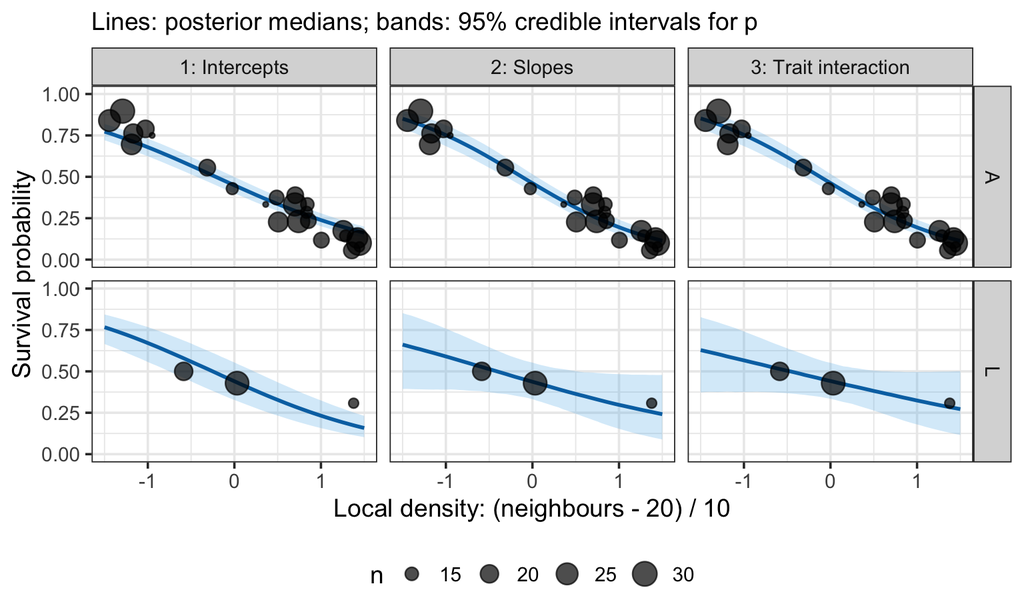

```r
shown_species <- c("A", "L")
regression_plot <- regression_curves |>
  filter(species %in% shown_species) |>
  ggplot(aes(x, median)) +
  geom_ribbon(aes(ymin = lower, ymax = upper), fill = "#56b4e9", alpha = 0.25) +
  geom_line(colour = "#0072b2", linewidth = 1) +
  geom_point(
    data = filter(reg_data, species %in% shown_species),
    aes(y = suv / n, size = n),
    inherit.aes = TRUE,
    alpha = 0.7
  ) +
  facet_grid(
    species ~ model,
    labeller = labeller(
      model = c(
        intercepts = "1: Intercepts",
        slopes = "2: Slopes",
        traits = "3: Trait interaction"
      )
    )
  ) +
  coord_cartesian(ylim = c(0, 1)) +
  labs(
    x = "Local density: (neighbours - 20) / 10",
    y = "Survival probability",
    subtitle = "Lines: posterior medians; bands: 95% credible intervals for p"
  ) +
  theme(legend.position = "bottom")
regression_plot
```

A has 24 quadrats; L has three. Compare the common slope in Model 1 with the varying slopes in Models 2–3. Bands are 95% credible intervals for probabilities of these observed species, not intervals for future counts. Check the observed density range before interpreting the ends of a curve.

The next figure shows **where slopes pool toward**. Points and intervals summarize species slopes; point size indicates quadrat count. The dashed line and grey band show the group-mean slope and its uncertainty. Model 2 shares one mean; Model 3 shares a trait-dependent mean. This does not display no-pooling estimates, so it does not measure each species’ amount of shrinkage.

**Show R code**

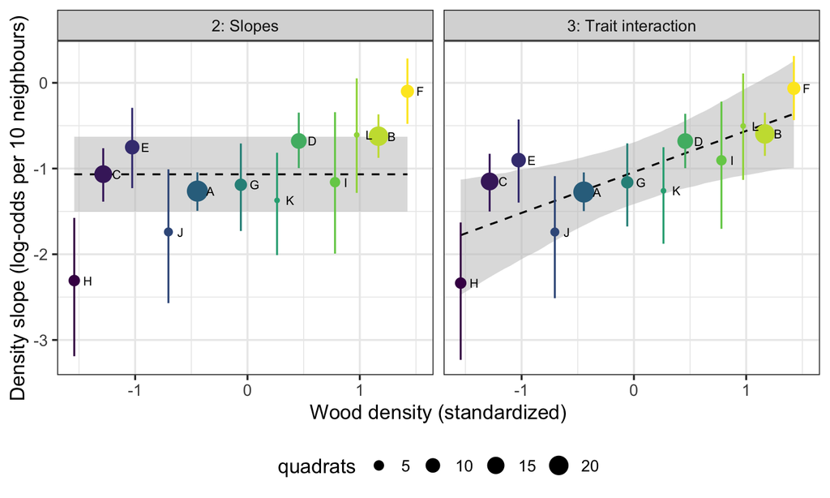

```r
slope_rows <- list()
mean_rows <- list()
u_grid <- seq(min(species_info$u), max(species_info$u), length.out = 61)
row_id <- 0L
for (model_name in c("slopes", "traits")) {
  reg_draws <- regression_fits[[model_name]]$draws
  for (j in seq_len(nrow(species_info))) {
    slope_draws <- reg_draws[[paste0("beta[", j, "]")]]
    row_id <- row_id + 1L
    slope_rows[[ row_id]] <- tibble(
      model = model_name,
      species = species_info$species[j],
      u = species_info$u[j],
      quadrats = species_info$quadrats[j],
      median = median(slope_draws),
      lower = quantile(slope_draws, 0.025),
      upper = quantile(slope_draws, 0.975)
    )
  }
  trait_slope <- rep(0, nrow(reg_draws))
  if (model_name == "traits") {
    trait_slope <- reg_draws[["gamma[2,2]"]]
  }
  mean_draws <- outer(trait_slope, u_grid)
  mean_draws <- sweep(mean_draws, 1, reg_draws[["gamma[2,1]"]], "+")
  mean_rows[[model_name]] <- tibble(
    model = model_name,
    u = u_grid,
    median = apply(mean_draws, 2, median),
    lower = apply(mean_draws, 2, quantile, probs = 0.025),
    upper = apply(mean_draws, 2, quantile, probs = 0.975)
  )
}
species_slopes <- bind_rows(slope_rows)
mean_slopes <- bind_rows(mean_rows)
ggplot(species_slopes, aes(u, median)) +
  geom_ribbon(
    data = mean_slopes,
    aes(ymin = lower, ymax = upper),
    fill = "grey75",
    alpha = 0.5
  ) +
  geom_line(data = mean_slopes, linetype = "dashed") +
  geom_linerange(aes(ymin = lower, ymax = upper, colour = u)) +
  geom_point(aes(colour = u, size = quadrats)) +
  geom_text(aes(label = species), nudge_x = 0.08, hjust = 0, size = 3) +
  facet_wrap(
    ~model,
    nrow = 1,
    labeller = labeller(
      model = c(slopes = "2: Slopes", traits = "3: Trait interaction")
    )
  ) +
  scale_colour_viridis_c(guide = "none") +
  labs(
    x = "Wood density (standardized)",
    y = "Density slope (log-odds per 10 neighbours)"
  ) +
  theme(legend.position = "bottom")
```

Explain how Model 3 changes the expected slope for a weakly informed species. Then identify an observation-level predictor, a grouping variable and a possible group-level predictor in your own research.

**NoteOptional: model checks and fitting**

### Sampling and predictive checks

Use the same checks as for the mother-tree model. Inspect R-hat, effective sample sizes, divergences, treedepth and E-BFMI together. These are checks of computation; compare observations with predictions to assess the model as well.

```r
for (model_name in names(regression_fits)) {
  print(model_name)
  print(regression_fits[[model_name]]$diagnostics)
}
```

```
#> [1] "intercepts"
#> $num_divergent
#> [1] 0 0 0 0
#>
#> $num_max_treedepth
#> [1] 0 0 0 0
#>
#> $ebfmi
#> [1] 0.7577838 0.7776855 0.7002847 0.7348270
#>
#> [1] "slopes"
#> $num_divergent
#> [1] 0 0 0 0
#>
#> $num_max_treedepth
#> [1] 0 0 0 0
#>
#> $ebfmi
#> [1] 0.7818918 0.7374342 0.7786564 0.7680402
#>
#> [1] "traits"
#> $num_divergent
#> [1] 0 0 0 0
#>
#> $num_max_treedepth
#> [1] 0 0 0 0
#>
#> $ebfmi
#> [1] 0.7590619 0.6696609 0.8134426 0.7450163
```

This Model 3 check replicates counts at each observed quadrat’s density and seedling count, then compares species totals. It includes binomial variation; the curve bands above do not. Totals can miss within-species density patterns, so also inspect points against the curves.

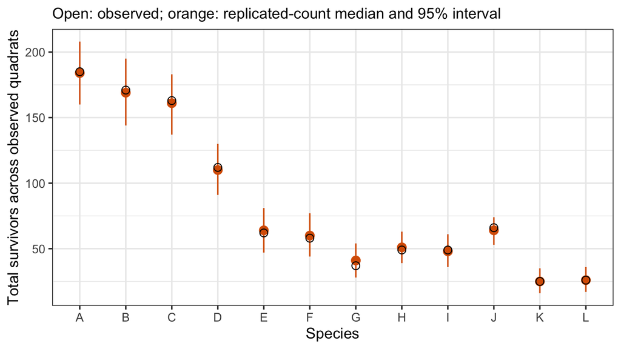

```r
set.seed(20261030)
trait_draws <- regression_fits$traits$draws
replicated_species <- matrix(
  0,
  nrow = nrow(trait_draws),
  ncol = nrow(species_info)
)
for (i in seq_len(nrow(reg_data))) {
  j <- as.integer(reg_data$species[i])
  p_draws <- plogis(
    trait_draws[[paste0("alpha[", j, "]")]] +
      trait_draws[[paste0("beta[", j, "]")]] * reg_data$x[i]
  )
  replicated_species[, j] <- replicated_species[, j] +
    rbinom(length(p_draws), size = reg_data$n[i], prob = p_draws)
}
regression_ppc <- reg_data |>
  group_by(species) |>
  summarise(observed = sum(suv), .groups = "drop") |>
  mutate(
    median = apply(replicated_species, 2, median),
    lower = apply(replicated_species, 2, quantile, probs = 0.025),
    upper = apply(replicated_species, 2, quantile, probs = 0.975)
  )
ggplot(regression_ppc, aes(species, median)) +
  geom_pointrange(aes(ymin = lower, ymax = upper), colour = "#d95f02") +
  geom_point(aes(y = observed), shape = 1, size = 3) +
  labs(
    x = "Species",
    y = "Total survivors across observed quadrats",
    subtitle = "Open: observed; orange: replicated-count median and 95% interval"
  )
```

Counts are assumed conditionally independent given predictors and species effects. Overdispersion or shared spatial effects may require extending the model.

### New inference in a prepared environment

This optional `brms` fit matches Model 3’s structure and priors. `center = FALSE` keeps the intercept prior at `x = u = 0`. Use the saved results for the walkthrough; participants do not need to install a toolchain.

```r
library(brms)
trait_fit_brms <- brm(
  bf(f_traits, center = FALSE),
  data = reg_data,
  family = binomial(link = "logit"),
  prior = c(
    prior(normal(0, 1.5), class = "Intercept"),
    prior(normal(0, 1.5), class = "b"),
    prior(normal(0, 0.7), class = "sd"),
    prior(lkj(2), class = "cor")
  ),
  backend = "cmdstanr",
  seed = 20261029,
  chains = 4,
  cores = 1,
  iter = 2000,
  warmup = 1000,
  control = list(adapt_delta = 0.98)
)
summary(trait_fit_brms)
pp_check(trait_fit_brms)
```

The instructor can regenerate all three saved fits with `Rscript R/precompute_day3_regression.R`. The full implementation is in `stan/cndd_hierarchical.stan`; matrix-factorization details are not required here.

In a frequentist fit, limited information can yield a singular covariance estimate (a near-zero variance or extreme correlation). Priors can help regularize these parameters, but do not create information or guarantee reliable inference. See [lme4’s discussion](https://lme4.github.io/lme4/reference/isSingular.html).

**TipSolution and instructor notes**

Ask readers to identify the count likelihood, the pair of lines implementing the shared Normal prior, and the inverse-logit transformation. The code can be read together without running a new fit. Do not repeat the lecture’s three-model comparison as another plotting task.

All trees inform the shared parameters `mu` and `sigma`; this connects their posterior intercept estimates. Independent standardized priors for `z_tilde` do not imply independent posterior tree estimates. `plogis(mu)` is not generally the mean survival probability across groups. Non-centering is an equivalent representation with the stated priors, not a guarantee of better sampling.

For the prepared result, Tree A’s mean survival probability is 0.34, with a 95% credible interval of [0.19, 0.54]. The predictive intervals for survivor counts answer a different question. The same seed, probabilities and seedling counts are used in the lecture’s mother-tree predictive check.

For regression, Model 1 shares a slope; Models 2–3 allow slopes to vary. Model 3 pools toward the trait-dependent mean, not one common slope. A positive interaction implies weaker negative density responses as wood density increases. Compare uncertainty in A and L without assuming every small group shrinks equally. The saved fits allow residual intercept–slope correlation; the lecture’s short Stan examples omit it. The original allometry model uses a different likelihood but the same hierarchy. No singular-fit outcome is claimed for this example.